# OTC Derivatives Pricing & Dynamics

Author

Brayden Boyko

## Options

Options are financial instruments that grant the buyer the right, but not the obligation, to buy or sell an underlying asset at a predetermined price before or at expiration. OTC options are highly customizable and often structured to meet specific client needs.

#### Vanilla Options:

- Call Options: Right to buy an asset at a strike price.
- Put Options: Right to sell an asset at a strike price.

The Black-Scholes model is widely used for pricing vanilla options:
$$\frac{\partial V}{\partial t} + \frac{1}{2} \sigma^2 S^2 \frac{\partial^2 V}{\partial S^2} + r S \frac{\partial V}{\partial S} - r V = 0$$

Where:

- 𝑉: price of the option
- 𝑡: time
- 𝑆: the current price of the underlying asset
- 𝜎: volatility of the underlying asset
- 𝑟: the risk-free interest rate

#### Exotic Options:

- Barrier Options: Activated or deactivated when the underlying reaches a certain level.
- Knock-in (only exists if a level is reached).
- Knock-out (ceases to exist beyond a level).

**Asian Options:** Payoff depends on the average price over time rather than the final price.

- Lookback Options: Strike price is determined retrospectively based on the asset’s best or worst performance.
- Binary (Digital) Options: Pays a fixed amount if a condition is met.

**Structured Options:**

- Range Accrual Options: Payoffs depend on how often an asset remains within a predefined range.
- Cliquet Options: A series of at-the-money options that reset at fixed intervals.
- Quanto Options: An option on an asset denominated in a foreign currency but settled in domestic currency.

Exotic options require Monte Carlo simulations, binomial trees, or finite-difference methods.

**Binomial Trees**
$$V = \frac{1}{1+r} \left[ p \cdot V_u + (1-p) \cdot V_d \right]$$

Where:

- 𝑉: present value of the option.
- 𝑟: risk-free interest rate.
- 𝑝: probability of an upward movement in the asset price.
- 𝑉𝑢: value of the option if the price goes up.
- 𝑉𝑑: value of the option if the price goes down.

The probabilities 𝑝 and 1 − 𝑝 are given by:

$$p = \frac{e^{(r-\delta) \Delta t} - d}{u - d}$$

where:

$$u = e^{\sigma \Delta t}$$

$$d = \frac{1}{u}$$

- Δ𝑡: length of each time step.
- 𝜎: volatility of the underlying asset.
- 𝛿: dividend yield (if any).

**Finite-Difference Method**
$$\begin{equation}
V_{i,j} = \Delta t \left[ \frac{1}{2} \sigma^2 i^2 V_{i-1,j+1} + r i V_{i,j+1} - r V_{i,j} \right] + V_{i,j+1}
\end{equation}$$

Where:

- 𝑉: option value at the i-th asset price and j-th time step.
- Δ𝑡: time step size.
- 𝜎: volatility of the underlying asset.
- 𝑟: risk-free interest rate.

#### Taylor Series Expansion For P&L Attribution

A Taylor series expansion should define the totality of change in price for a security. It takes into account:

- First and higher orders for each pricing input, or risk factors; e.g., underlying, IR, time…
- Any cross relationships between risk factors; e.g., a stock price and its implied volatility.

**Delta**

The first-order derivative of the option price with respect to changes in the underlying price
$$\begin{aligned}
delta \approx \frac{P_{S+\Delta S}-P_{S-\Delta S}}{2 \Delta S} \\
\mbox{where P is the option price}
\end{aligned}$$

For call options:

- Out-of-The-Money (“OTM”) when Δ < 0.5
- At-the-Money (“ATM”) when = 0.5 In-the-Money (“ITM”) when Δ > 0.5

**Gamma**

The second-order derivative of the option price with respect to changes in the underlying price.

$$\begin{aligned}
gamma \approx \frac{P_{S+\Delta S}-2P_S +P_{S-\Delta S}}{\Delta S^2} \\
\mbox{where P is the option price}
\end{aligned}$$

**Vega**

The first-order derivative of the option price with respect to changes in implied volatility.

$$\begin{aligned}
vega \approx \frac{P_{\sigma+\Delta \sigma}-P_{\sigma-\Delta \sigma}}{2 \Delta \sigma} \\
\mbox{where P is the option price}
\end{aligned}$$

**Theta**

The first-order derivative of the option price with respect to changes in time to expiry (time decay).

$$\begin{aligned}
\Theta_{call} = -\frac{\partial c}{\partial T} =
-\frac{Se^{(b-r)T}N(d_{1})\sigma}{2\sqrt{T}} - (b-r)Se^{(b-r)T}N(d_{1}) - rXe^{-rT}N(d_{2}) \\
\Theta_{put} = -\frac{\partial p}{\partial T} =
-\frac{Se^{(b-r)T}N(d_{1})\sigma}{2\sqrt{T}} + (b-r)Se^{(b-r)T}N(d_{1}) + rXe^{-rT}N(d_{2})
\end{aligned}$$

**P&L Attribution**

Taylor series expansion is used to approximate changes in the option’s price (P&L attribution) due to changes in the underlying variables like Delta, Gamma, Vega, and Theta.

$$\Delta P \approx \Delta S \cdot \Delta + \frac{1}{2} \Delta S^2 \cdot \Gamma + \Delta \sigma \cdot \nu + \Delta t \cdot \Theta$$

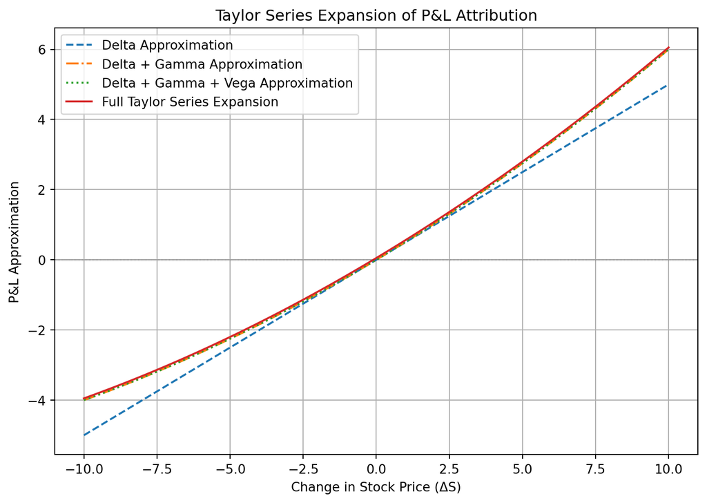

## Forwards

A forward contract is a customized agreement between two parties to buy or sell an asset at a specified future date for a pre-agreed price. OTC forwards allow flexibility in asset selection, notional amount, and expiration.

#### FX Forwards

Used for hedging or speculating on currency exchange rate movements. Can be deliverable or non-deliverable (NDFs) where the contract is settled in cash.

$$F = S \left( \frac{1 + r_d}{1 + r_f} \right)^T$$

Where:

- F: Forward rate
- S: Spot rate
- rd: Domestic interest rate
- rf: Foreign interest rate
- T: Time to maturity (years)

#### Commodity Forwards

Applied to commodities like oil, gold, and agricultural products. Used by producers and consumers to lock in future prices.

$$F = S e^{(r + c - y)T}$$

Where:

- 𝐹: Futures price.
- 𝑆: Spot price of the commodity.
- 𝑟: Risk-free interest rate.
- 𝑐: Cost of carry (including storage costs, insurance, etc.).
- 𝑦: Convenience yield.
- 𝑇: Time to maturity, usually in years.

#### Equity Forwards

Contracts on individual stocks or indices. Often used for dividend arbitrage, tax-efficient hedging, or equity financing.

$$F = S e^{(r - d)T}$$

Where:

- 𝐹: Futures price.
- 𝑆: Spot price of the commodity.
- 𝑟: Risk-free interest rate.
- d: Dividend.
- 𝑇: Time to maturity, usually in years.

#### Interest Rate Forwards

Forward Rate Agreements (FRAs): Agreement to pay/receive the difference between a fixed and floating interest rate.

$$\text{FRA Value} = \frac{N \cdot (R - R_f) \cdot T}{1 + R_f \cdot T}$$

Where:

- N: Notional principal ammount.
- R: Fixed rate.
- Rf: Forward rate per period.
- T: Time to end of period (years)

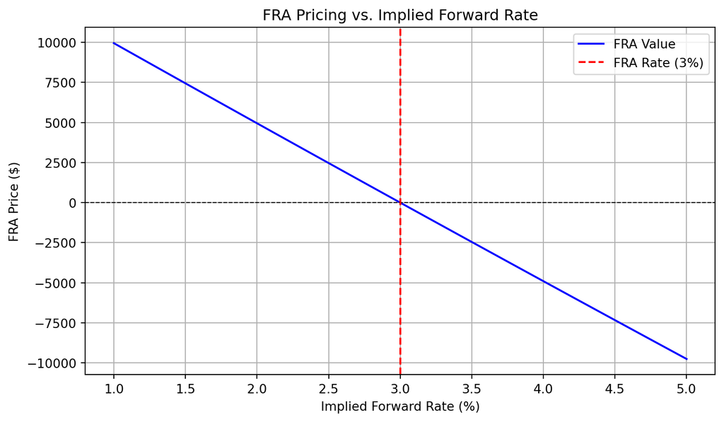

## Swaps

Swaps involve the exchange of cash flows based on different financial variables. They are widely used for hedging, yield enhancement, and risk transformation.

#### Interest Rate Swaps (IRS)

Exchange of fixed and floating interest rate payments.

**Plain vanilla IRS:** Fixed-for-floating swap based on LIBOR, SOFR, or EURIBOR.

$$\text{Net Cash Flow} = \left( \frac{1 - (1 + r_f)^{-T}}{r_f} \right) \cdot (r_f - r_{\text{fixed}}) \cdot N$$

Where:

- 𝑟𝑓: Floating interest rate.
- 𝑟fixed: Fixed interest rate.
- 𝑇: Time to maturity (in years).
- 𝑁: Notional principal amount.

**Basis swaps:** Floating-to-floating swaps using different benchmarks.

$$\text{Net Cash Flow} = N \cdot (\text{Index}_1 - \text{Index}_2) \cdot T$$

Where:

- Index1: 1st Floating interest rate.
- Index2: 2nd Floating interest rate.
- 𝑇: Time to maturity (in years).
- 𝑁: Notional principal amount.

**Inflation swaps:** Fixed cash flows exchanged for inflation-linked cash flows.

$$\text{Net Cash Flow} = N \cdot \left( \frac{\text{CPI}_{\text{end}}}{\text{CPI}_{\text{start}}} - 1 \right) - N \cdot (r_{\text{fixed}} \cdot T)$$

Where:

- CPIend: Consumer Price Index at the end of the period.
- CPIstart: Consumer Price Index at the start of the period.
- 𝑟fixed: Fixed interest rate.
- 𝑇: Time to maturity (in years).
- 𝑁: Notional principal amount.

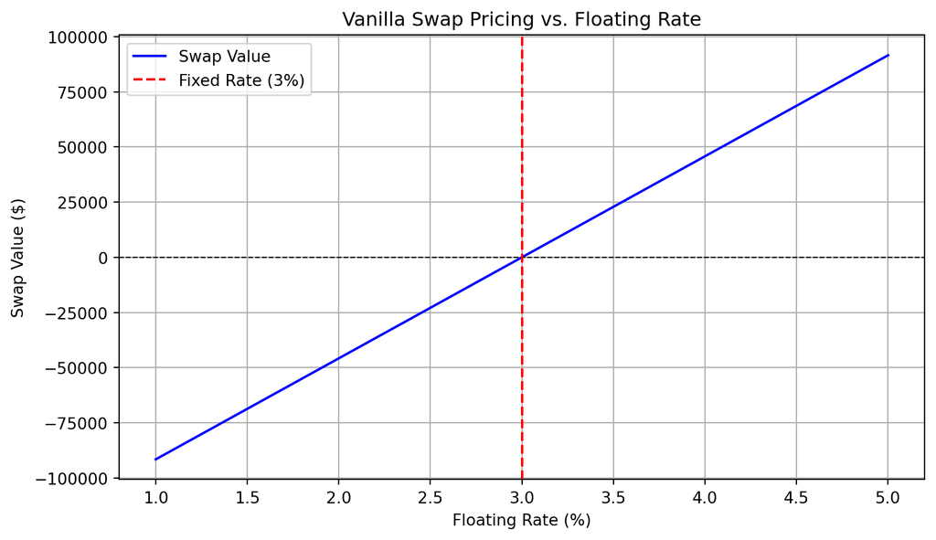

#### Currency Swaps

Exchange of principal and interest payments in different currencies.

**Fixed-for-fixed currency swap:** Fixed rate payments exchanged across two currencies.

$$\text{Net Cash Flow} = N_{\text{domestic}} \cdot r_{\text{domestic}} \cdot T - N_{\text{foreign}} \cdot r_{\text{foreign}} \cdot \frac{1}{e}$$

Where:

- 𝑁domestic: Notional principal amount in the domestic currency.
- 𝑟domestic: Fixed interest rate in the domestic currency.
- 𝑁foreign: Notional principal amount in the foreign currency.
- 𝑟foreign: Fixed interest rate in the foreign currency.
- 𝑒: Exchange rate between the domestic and foreign currencies.
- 𝑇: Time to the next payment date (in years).

**Fixed-for-floating currency swap:** One leg remains floating.

$$\text{Net Cash Flow} = N_{\text{domestic}} \cdot r_{\text{fixed}} \cdot T - N_{\text{foreign}} \cdot r_{\text{floating}} \cdot \frac{1}{e}$$

Where:

- 𝑁domestic: Notional principal amount in the domestic currency.
- 𝑟fixed: Fixed interest rate in the domestic currency.
- 𝑁foreign: Notional principal amount in the foreign currency.
- 𝑟floating: Floating interest rate in the foreign currency.
- 𝑒: Exchange rate between the domestic and foreign currencies.
- 𝑇: Time to the next payment date (in years).

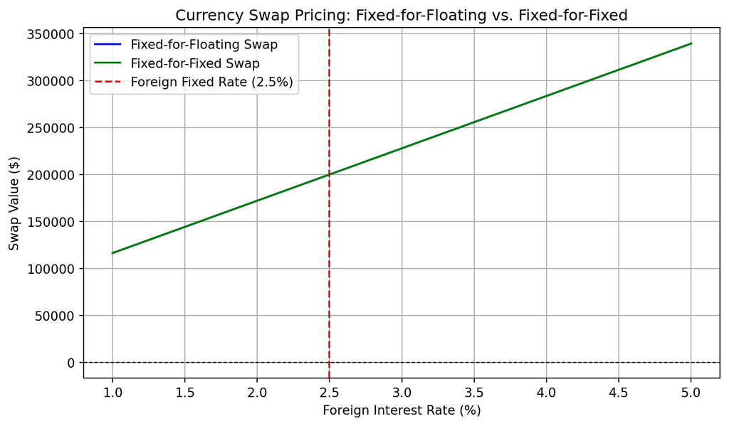

#### Commodity Swaps

Exchange of a floating commodity price for a fixed price. Used by producers and consumers to stabilize cash flows.

- 𝑁: Notional principal amount.
- Fixed Price: Agreed-upon fixed price of the commodity.
- Floating Price: Market price of the commodity at the time of the cash flow.
- 𝑇: Time to the next payment date (in years).

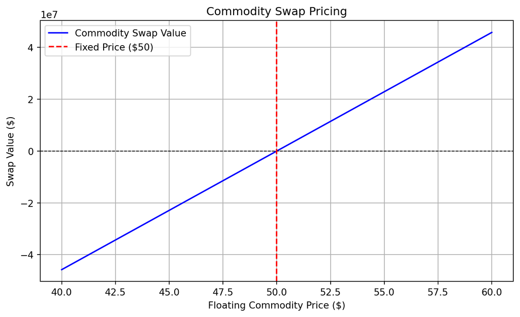

#### Total Return Swaps (TRS)

One party pays total return on an asset (e.g., equity or bond), the other pays a fixed/floating rate. Used for leverage, synthetic exposure, or regulatory capital relief.

$$\text{Net Cash Flow} = N \cdot \left( \text{Total Return} - \text{Interest Payments} \right) \cdot T$$

Where:

- 𝑁: Notional principal amount.
- Total Return: Return on the specified asset (including both capital gains and any dividends or interest).
- Interest Payments: Market price of the commodity at the time of the cash flow.
- 𝑇: Time to the next payment date (in years).

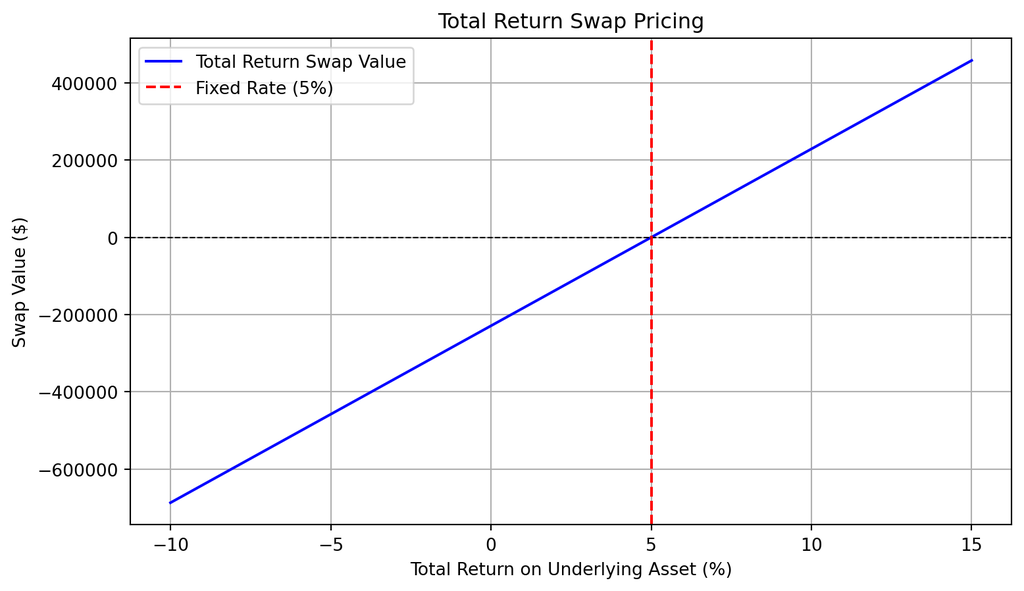

## Volatility

Volatility derivatives allow investors to hedge or speculate on market volatility independent of price direction.

#### Variance Swaps

Payoff based on the difference between realized variance and a pre-agreed strike variance. Useful for exposure to pure volatility risk without delta exposure.

$$\text{Net Cash Flow} = N_{\text{var}} \cdot (\sigma_{\text{realized}}^2 - K_{\text{var}})$$

Where:

- 𝑁var: Notional amount of the variance swap.
- 𝜎realized: Realized variance of the underlying asset over the life of the swap.
- 𝐾var: Strike variance (the variance agreed upon at the inception of the swap).

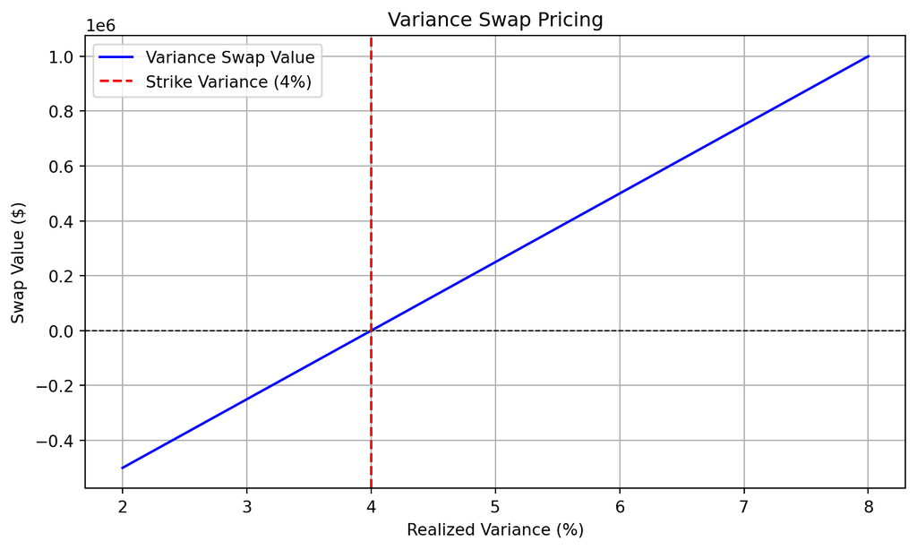

2. Volatility Swaps

Payoff is linked to the difference between realized and implied volatility.

$$\text{Net Cash Flow} = N_{\text{vol}} \cdot (\sigma_{\text{realized}} - K_{\text{vol}})$$

Where:

- 𝑁vol: Notional amount of the volatility swap.
- 𝜎realized: Realized volatility of the underlying asset over the life of the swap.
- 𝐾vol: Strike volatility (the volatility agreed upon at the inception of the swap).

#### Dispersion Trading

Buying/selling index volatility versus individual stock volatilities. Used to exploit correlation discrepancies between assets.

$$\text{Net Cash Flow} = N \cdot \left( \sigma_{\text{index}} - \frac{1}{n} \sum_{i=1}^{n} \sigma_{\text{stock},i} \right) \cdot T$$

Where:

- 𝑁: Notional amount.
- 𝜎index: Implied volatility of the index.
- 𝜎stock,i: Implied volatility of the 𝑖-th individual stock.
- n: Number of individual stocks.
- 𝑇: Time to the next reset date (in years).

[figure not shown]

Risk management involves gamma hedging and dynamic adjustments to maintain vega neutrality. To achieve risk neutrality, the following can be calculated:

$$\Delta_{\text{total}} = 0
\Gamma_{\text{total}} = 0
\nu_{\text{total}} = 0
\Theta_{\text{total}} = 0$$

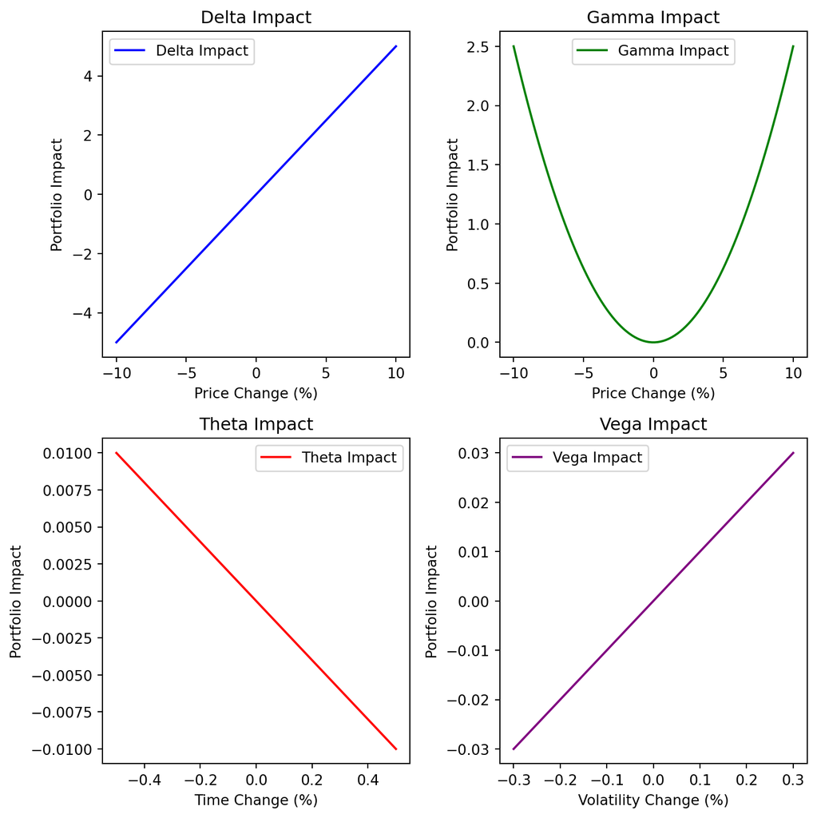

To hedge each of the Greeks (delta, gamma, theta, and vega), we would implement different strategies. Each hedge involves taking positions in options (or other instruments) to neutralize the risk associated with each Greek.

- **Hedging Delta (Δ):** Delta neutrality is achieved by taking positions in options or other assets to offset the change in the price of the underlying asset.Hedge Strategy: Buy or sell the underlying asset in proportion to the delta of the option. If you have a call option with a delta of 0.5, to hedge this, you would short 0.5 units of the underlying asset (assuming 1 option contract corresponds to 1 unit of the underlying). Example: If you hold 100 call options (each with a delta of 0.5), you would short 50 units of the underlying asset.
- **Hedging Gamma (Γ):** Gamma neutrality focuses on minimizing the convexity risk by adjusting the delta over time. Hedge Strategy: To hedge gamma, you need to take positions in options with opposite gamma, adjusting the portfolio as the market moves. If you have positive gamma, you may hedge by taking a position in options with negative gamma, or you could hedge by adjusting your delta hedge as the price of the underlying changes. Example: If you hold a position with a gamma of 0.05, you could balance this out by buying or selling more options or the underlying asset as the price changes.
- **Hedging Theta (Θ):** Theta neutrality involves minimizing the time decay effect on options. Hedge Strategy: To hedge theta, you can take positions in options with offsetting time decay, typically through spreads or through holding long and short options with different expiration dates. Example: To hedge a short position in an option (which would have negative theta), you could take a long position in a similar option with a longer time to expiration, or use a calendar spread (buy a longer-dated option while selling a shorter-dated one).
- **Hedging Vega (V):** Vega neutrality focuses on minimizing the risk due to volatility changes. Hedge Strategy: You can hedge vega exposure by taking positions in options with opposite vega. This is often achieved through volatility swaps or a position in options with different implied volatility sensitivities. Example: If you have long options with high vega, you could hedge by selling options or entering into volatility instruments that would benefit from changes in volatility.

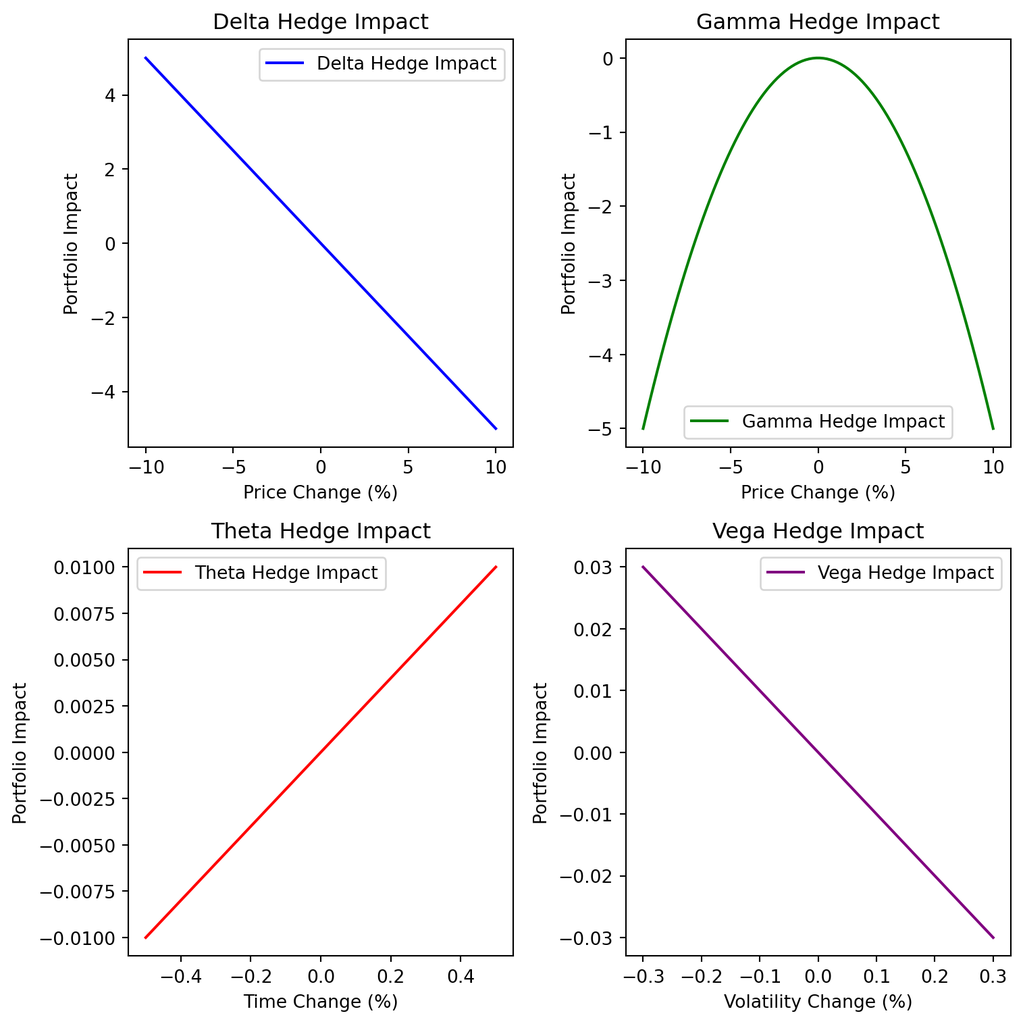

## Structured Products

Structured products are pre-packaged investment strategies that combine traditional financial instruments, such as bonds, with derivatives (options, swaps) to create customized risk-return profiles.

**Use Cases for Structured Products**

- Hedging: Investors can use structured products to hedge against specific risks, such as interest rate changes or market downturns.
- Yield Enhancement: Investors looking for higher yields can use structured products, such as reverse convertibles or credit-linked notes, which offer higher returns compared to traditional bonds.
- Capital Protection: Investors may seek capital protection in volatile markets, with products that offer partial or full principal protection.

#### Collateralized Debt Obligations (CDOs)

CDOs were originally developed for the corporate debt markets, but they later became vehicles for refinancing mortgage-backed securities. The creation of CDOs dates back to 1987 when Drexel Burnham Lambert first assembled portfolios of junk bonds into these structured products. The structure of a CDO involves gathering income from a collection of collateralized debt instruments and allocating the collected income to a prioritized set of CDO securities. This allows banks to reduce the amount of risk they hold on their balance sheet and transform relatively illiquid securities into more liquid ones. However, CDOs backed by risky subprime mortgages were a significant factor in the financial crisis between 2007 and 2009. Despite their risks, CDOs remain a viable tool for diversifying risk and creating more liquid capital for investment banks.

$$\text{CDO} = \sum{i=1}^{n} (\text{Principal}{i} \times \text{CouponRate}{i}) - \sum_{j=1}^{m} (\text{Loss}_{j})$$

Where:

- 𝑛: Number of tranches.
- Principal𝑖: Principal amount of tranche 𝑖.
- CouponRate𝑖: Coupon rate of tranche 𝑖.
- 𝑚: Number of loss events.
- Loss𝑗: Loss amount of event 𝑗.

[figure not shown]

#### Credit Defualt Swaps (CDS)

A Credit Default Swap (CDS) is a financial derivative that allows an investor to “swap” or offset their credit risk with that of another investor. In simple terms, it functions like insurance against the default of a borrower.

- **Protection Buyer:** The party that pays periodic premiums in exchange for protection against the default of a reference entity (e.g., a corporation or government issuing the bond).
- **Protection Seller:** The party that receives premiums and agrees to compensate the protection buyer in case the reference entity defaults.
- **Reference Entity:** The underlying asset whose credit risk is being transferred. It is typically a bond or loan issued by a corporation or government.
- **Premium Payments:** Regular payments made by the protection buyer to the protection seller. These are similar to insurance premiums.
- **Credit Event:** The occurrence of a specified event (e.g., default, bankruptcy) that triggers the protection seller to pay the protection buyer.
- **Settlement:** If a credit event occurs, the protection seller compensates the protection buyer, either through a cash payment or physical delivery of the reference asset.

$$\text{CDO} = \sum{i=1}^{n} (\text{Principal}{i} \times \text{CouponRate}{i}) - \sum_{j=1}^{m} (\text{Loss}_{j})$$

Where:

- 𝑛: Number of tranches.
- Principal𝑖: Principal amount of tranche 𝑖.
- CouponRate𝑖: Coupon rate of tranche 𝑖.
- 𝑚: Number of loss events.
- Loss𝑗: Loss amount of event 𝑗.

**Protection Leg**

$$\text{Protection} = \sum{i=1}^{n} (\text{DefaultProb}{i} \times \text{LossGivenDefault} \times \text{DiscountFactor}{i})$$

**Premium Leg**

$$\text{Premium} = \sum{i=1}^{m} (\text{PremiumPayment}{i} \times \text{DiscountFactor}{i})$$

[figure not shown]

#### Building Structured Products

Structured products can be very complex, and they are often tailored to meet the specific needs of investors, combining various derivatives to achieve the desired exposure to underlying assets.

$$\text{StructuredProduct} = \sum{i=1}^{n} (\text{OptionValue}{i}) + \sum{j=1}^{m} (\text{ForwardValue}{j}) + \sum{k=1}^{p} (\text{SwapValue}{k}) + \sum{l=1}^{q} (\text{VolatilityProductValue}_{l})$$

Where:

- 𝑛: Number of options.
- OptionValue𝑖: Value of option 𝑖.
- 𝑚: Number of forwards.
- ForwardValue𝑗: Value of forward 𝑗.
- 𝑝: Number of swaps.
- SwapValue𝑘: Value of swap 𝑘.
- 𝑞: Number of volatility products.
- VolatilityProductValue 𝑙: Value of volatility product 𝑙.

Each component can be further broken down into its own specific formulas, such as the Black-Scholes formula for options, discounted cash flows for forwards, and present value calculations for swaps. The values of each component depend on market conditions, underlying assets, and specific contract terms. For example:

$$\text{SP} = \sum{i=1}^{n} \left( S_0 \Phi(d_1) - K e^{-rT} \Phi(d_2) \right) + \sum_{j=1}^{m} \left( (S_t - F_t) e^{-r(T-t)} \right) + \sum_{k=1}^{p} \left( \sum_{i=1}^{n} \left[ (R_f - R_v) \times \frac{Notional}{1 + r_i} \right] \right) + \sum_{l=1}^{q} \left( ( \sigma_{\text{realized}}^2 - K_{\text{variance}}^2 ) \times Notional \right)$$

###### Example Structured Product

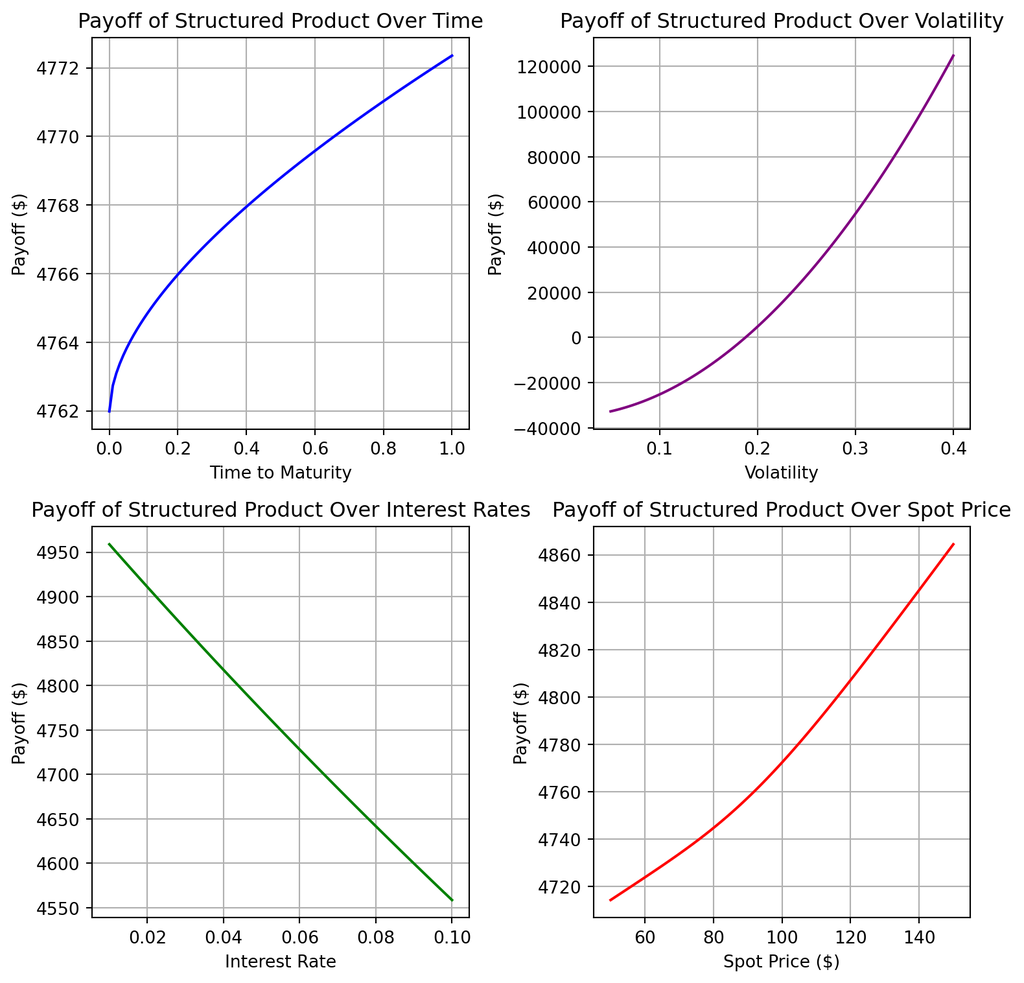

### Estimating Structured Product Payoffs

Estimating the products payoff when simulating data through a diffusion, mean-reversion, or levy mean-reversion process proves difficult for complex products with non-linear and often non-polynomial payoffs. To estimate the payoff, a piecewise polynomial fit can be utilized. However, this introduces the difficult challenge of estimating the knots in the function.

#### Piecewise Polynomial Fitting

Piecewise polynomial fitting is a technique used to approximate complex functions by dividing the domain into smaller segments and fitting separate polynomial functions to each segment. This method improves flexibility and accuracy compared to using a single high-degree polynomial. B-splines (Basis Splines) are a type of piecewise polynomial function used for smooth curve fitting and interpolation. They are constructed using a set of basis functions, which define the shape of the curve while ensuring continuity and smoothness at the segment boundaries (knots). Unlike traditional polynomial fitting, B-splines offer better numerical stability and flexibility by avoiding high-degree polynomials that can lead to oscillations. The degree of the B-spline determines its smoothness, with cubic B-splines (degree 3) being the most commonly used due to their balance between flexibility and computational efficiency. While this technique is rather useful in estimating payoffs given and underlying process, it introduces the challenge of defining the number of knots in the peicewise function.

#### K-Mean Clustering Estimation For Peicewise Points

K-means clustering is an unsupervised machine learning algorithm used to group data points into a predefined number of clusters, or groups, based on their similarities. It works by iteratively assigning each data point to the nearest cluster centroid and then recalculating these centroids to minimize the total distance between data points and their respective cluster centers. However, it assumes that clusters are spherical and equally sized, which may not always align with real-world data, making careful evaluation of its results essential. To define the complexity of the model a “centers” value must be applied. This can be approximated by using the number of derivatives in the product.